# HSC Survey Results

# Scots Bay Survey # 3 Results from 06/07/2026

## Survey Details

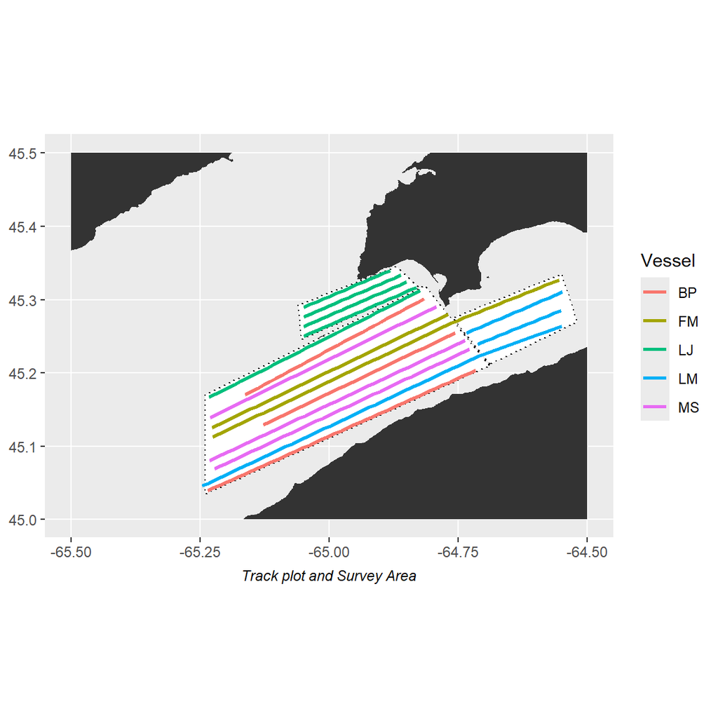

5 vessels ran various transects each in the Main Survey Box, the Fundy Monarch and Lady Melissa ran various lines in the Eastern Survey Box, and the Lady Janice ran four lines in the Northern Survey Box.

There was a plankton tow and replicate conducted and CTD cast by Lady Melissa.

No tags were applied during this survey.

Samples were obtained for target strength estimation.

### Tides Tables

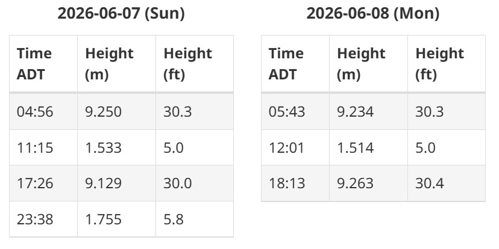

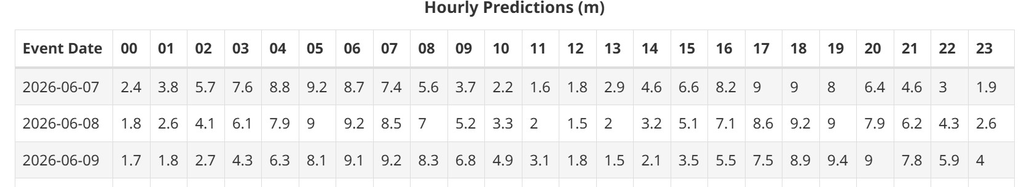

Tide Schedule for Margaretsville NS, Station #315m Source: www.waterlevels.gc.ca

### Acoustic Equipment

Each vessel was equipped with a Simrad ES38-18/200-18C combi (2-in-1) transducer prior to the survey that contains a 38kHz split beam and 200 kHz single beam transducer. Data was logged to the computer hard-drive for post-processing.

## Survey Results

### Main Results

The results are subject to change as DFO will re-evaluate data editing, area estimation and apply a target strength.

**Preliminary biomass prediction for Scots Bay using standardized parallel transects is 48,291mt, and with turnover applied 35,960mt.**

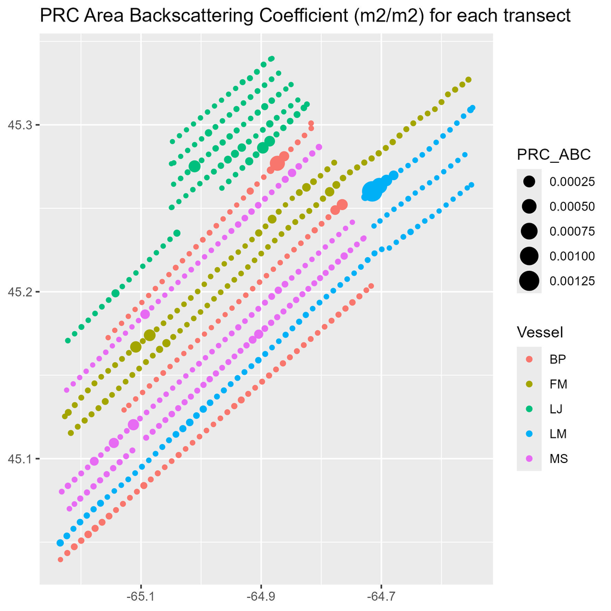

### Transect Details

Table 1: Transect Details

| Vessel | Transect # | Date/Time Start | Date/Time End | Start Lon | Start Lat | End Lon | End Lat | Location | Distance (km) | Speed |
| --- | --- | --- | --- | --- | --- | --- | --- | --- | --- | --- |
| BP | T01 | 2026-06-07 18:20 | 2026-06-07 21:25 | -65.236 | 45.039 | -64.717 | 45.203 | SB | 44.82 | 7.85 |
| BP | T02 | 2026-06-07 21:50 | 2026-06-07 23:46 | -64.757 | 45.255 | -65.128 | 45.129 | SB | 32.41 | 9.05 |
| BP | T03 | 2026-06-08 0:04 | 2026-06-08 1:59 | -65.163 | 45.170 | -64.817 | 45.301 | SB | 31.46 | 8.86 |
| FM | T01 | 2026-06-07 20:12 | 2026-06-07 23:12 | -65.226 | 45.112 | -64.764 | 45.268 | SB | 40.77 | 7.34 |
| FM | T03 | 2026-06-08 1:24 | 2026-06-08 4:03 | -64.770 | 45.280 | -65.227 | 45.125 | SB | 40.29 | 8.21 |
| FM | T02 | 2026-06-07 23:13 | 2026-06-08 0:32 | -64.764 | 45.268 | -64.555 | 45.327 | SB | 17.85 | 7.32 |
| LJ | T01 | 2026-06-07 18:48 | 2026-06-07 21:19 | -65.233 | 45.167 | -64.824 | 45.312 | SB | 36.45 | 7.82 |
| LJ | T02 | 2026-06-07 21:22 | 2026-06-07 22:36 | -64.831 | 45.317 | -65.050 | 45.250 | SB | 18.75 | 8.21 |
| LJ | T03 | 2026-06-07 22:43 | 2026-06-07 23:50 | -65.050 | 45.263 | -64.850 | 45.324 | SB | 17.10 | 8.27 |
| LJ | T04 | 2026-06-07 23:56 | 2026-06-08 0:59 | -64.861 | 45.333 | -65.049 | 45.277 | SB | 16.17 | 8.31 |
| LJ | T05 | 2026-06-08 1:04 | 2026-06-08 1:57 | -65.050 | 45.290 | -64.882 | 45.340 | SB | 14.36 | 8.77 |
| LM | T01 | 2026-06-07 18:50 | 2026-06-07 22:02 | -65.246 | 45.046 | -64.711 | 45.223 | SB | 47.06 | 7.94 |
| LM | T02 | 2026-06-07 22:02 | 2026-06-07 22:54 | -64.711 | 45.223 | -64.550 | 45.264 | SB | 13.52 | 8.42 |
| LM | T03 | 2026-06-07 23:02 | 2026-06-07 23:55 | -64.550 | 45.285 | -64.712 | 45.239 | SB | 13.76 | 8.41 |
| LM | T04 | 2026-06-08 0:04 | 2026-06-08 1:04 | -64.734 | 45.255 | -64.548 | 45.310 | SB | 15.94 | 8.61 |
| MS | T01 | 2026-06-07 19:39 | 2026-06-07 23:16 | -65.222 | 45.069 | -64.729 | 45.232 | SB | 47.55 | 7.10 |
| MS | T02 | 2026-06-07 23:22 | 2026-06-08 2:11 | -64.737 | 45.244 | -65.232 | 45.080 | SB | 44.91 | 8.61 |
| MS | T03 | 2026-06-08 2:35 | 2026-06-08 4:53 | -65.230 | 45.139 | -64.793 | 45.290 | SB | 38.66 | 9.08 |

### Survey Summary

Table 2: Acoustic Survey Results

| Vessel | Transect No. | Target Strength (db/kg) | Mean Sa (/m2) | Biomass Density (kg/m2) |
| --- | --- | --- | --- | --- |
| LM | T04 | -35.5 | -38.306 | 0.524 |
| BP | T03 | -35.5 | -45.643 | 0.097 |
| LJ | T03 | -35.5 | -46.660 | 0.077 |
| LJ | T01 | -35.5 | -46.993 | 0.071 |
| FM | T03 | -35.5 | -47.245 | 0.067 |
| MS | T02 | -35.5 | -48.948 | 0.045 |
| LJ | T02 | -35.5 | -49.455 | 0.040 |
| BP | T02 | -35.5 | -49.627 | 0.039 |
| MS | T01 | -35.5 | -50.475 | 0.032 |
| FM | T01 | -35.5 | -50.647 | 0.031 |
| MS | T03 | -35.5 | -51.160 | 0.027 |
| LM | T01 | -35.5 | -51.466 | 0.025 |
| BP | T01 | -35.5 | -51.863 | 0.023 |
| FM | T02 | -35.5 | -52.878 | 0.018 |
| LJ | T04 | -35.5 | -54.850 | 0.012 |
| LM | T02 | -35.5 | -57.857 | 0.006 |
| LJ | T05 | -35.5 | -58.395 | 0.005 |
| LM | T03 | -35.5 | -61.871 | 0.002 |

Note:  
Transects are listed from greatest to least backscatter.

Table 3: Survey Summary Table

| Layer | Target Strength | Area (km2) | Mean Sa | Density (kg/m2) | Biomass (tons) | Percent Area | Percent Biomass | Standard Error (tons) | Standard Error (%) |
| --- | --- | --- | --- | --- | --- | --- | --- | --- | --- |
| Main Box | -35.5 | 605.50810 | -49.1020 | 0.0456 | 26,419.246 | 74.0 | 54.7 | 4,704.60 | 17.81 |
| Northern Box | -35.5 | 80.94466 | -50.0553 | 0.0334 | 2,835.705 | 9.9 | 5.9 | 1,318.36 | 46.49 |
| Eastern Box | -35.5 | 132.26460 | -43.9186 | 0.1376 | 19,036.536 | 16.2 | 39.4 | 17,044.64 | 89.54 |

### Greatest Biomass Densities

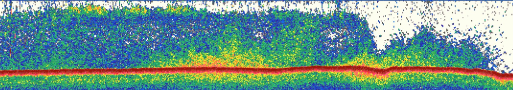

A snip from the transect with the greatest biomass density (kg/m2)

The single point with the largest biomass density (kg/m2) was recorded by **LM**, at the following location:

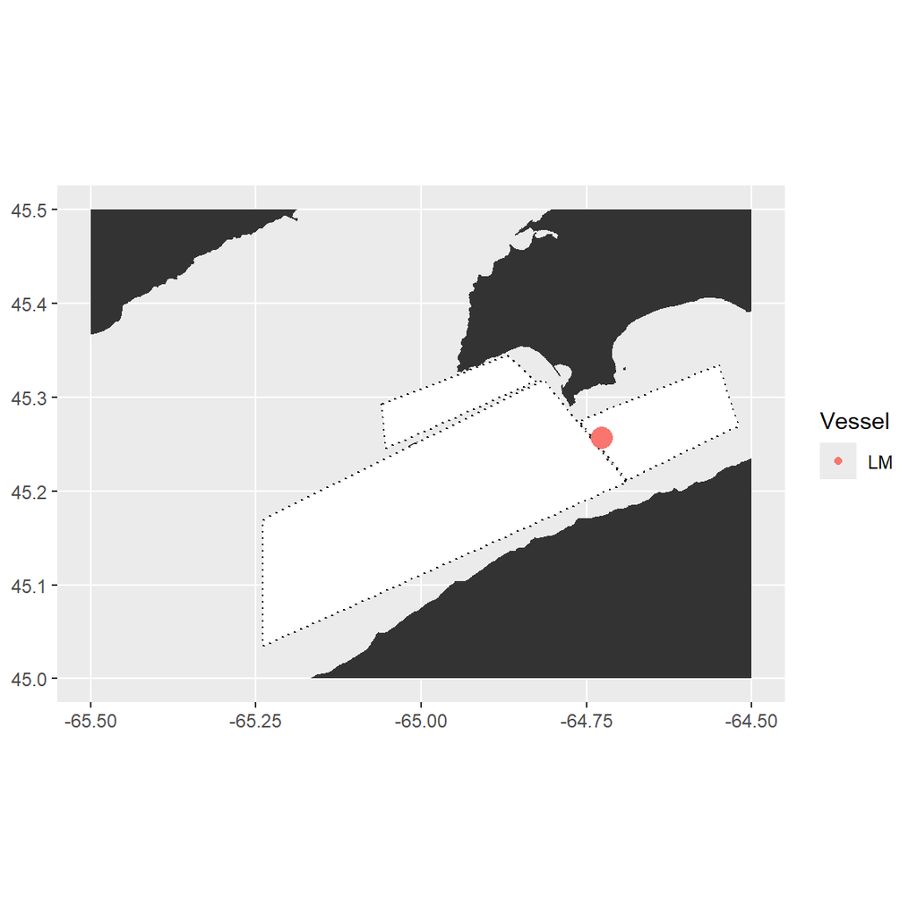

The transect with the greatest average biomass density (kg/m2) was recorded by **LM**, at the following location:

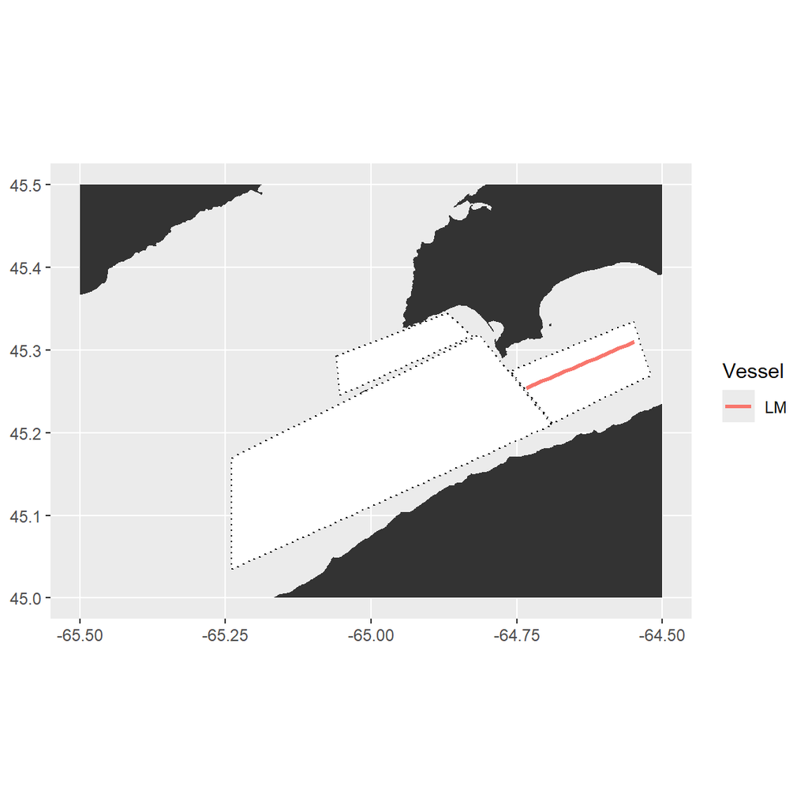

### Annual Summaries

This table does not include the biomass from adhoc surveys.

Table 4: Annual Comparison Table

| Ground | Survey Number | Current Year Survey Date | Current Year HSC Estimate | Current Year HSC Turnover Adjusted | Previous Year Survey Date | Previous Year HSC Estimate | Previous Year HSC Turnover Adjusted | Previous Year DFO Estimate | Previous Year DFO Turnover Adjusted |
| --- | --- | --- | --- | --- | --- | --- | --- | --- | --- |
| Scots Bay | 1 | 2026-05-10 | 29,384.44 | 29,384.44 | 2025-05-06 | 12,306.000 | 12,306 | NA | NA |
| Scots Bay | 2 | 2026-05-24 | 61,137.92 | 57,168.56 | 2025-05-21 | 120,045.000 | 118,023 | NA | NA |
| Scots Bay | 3 | 2026-06-07 | 48,291.49 | 35,959.64 | 2025-06-03 | 123,037.000 | 109,821 | NA | NA |
| Scots Bay | 4 | NA | NA | NA | 2025-06-16 | 14,184.000 | 0 | NA | NA |
| Scots Bay | 5 | NA | NA | NA | 2025-06-30 | 15,789.000 | 11,509 | NA | NA |
| Scots Bay | 6 | NA | NA | NA | 2025-07-14 | 7,114.000 | 5,137 | NA | NA |
| Scots Bay | 7 | NA | NA | NA | 2025-07-28 | 7,573.000 | 6,612 | NA | NA |
| Scots Bay | 8 | NA | NA | NA | 2025-08-11 | 5,164.476 | 4,916 | NA | NA |
| Scots Bay | 9 | NA | NA | NA | 2025-08-26 | 6,675.466 | 5,948 | NA | NA |
| Scots Bay | 10 | NA | NA | NA | 2025-09-08 | 4,180.432 | 3,169 | NA | NA |
| Scots Bay | 11 | NA | NA | NA | 2025-09-21 | 11,200.647 | 10,471 | NA | NA |

Table 5: Annual Summary Table

| Year | Ground | HSC Estimate | HSC Turnover Adjusted | DFO Estimate | DFO Turnover Adjusted |
| --- | --- | --- | --- | --- | --- |
| 2025 | Scots Bay | 327,269.0 | 287,912.0 | NA | NA |
| 2026 | Scots Bay | 138,813.8 | 122,512.6 | NA | NA |

## Vessel Performance

### Speed

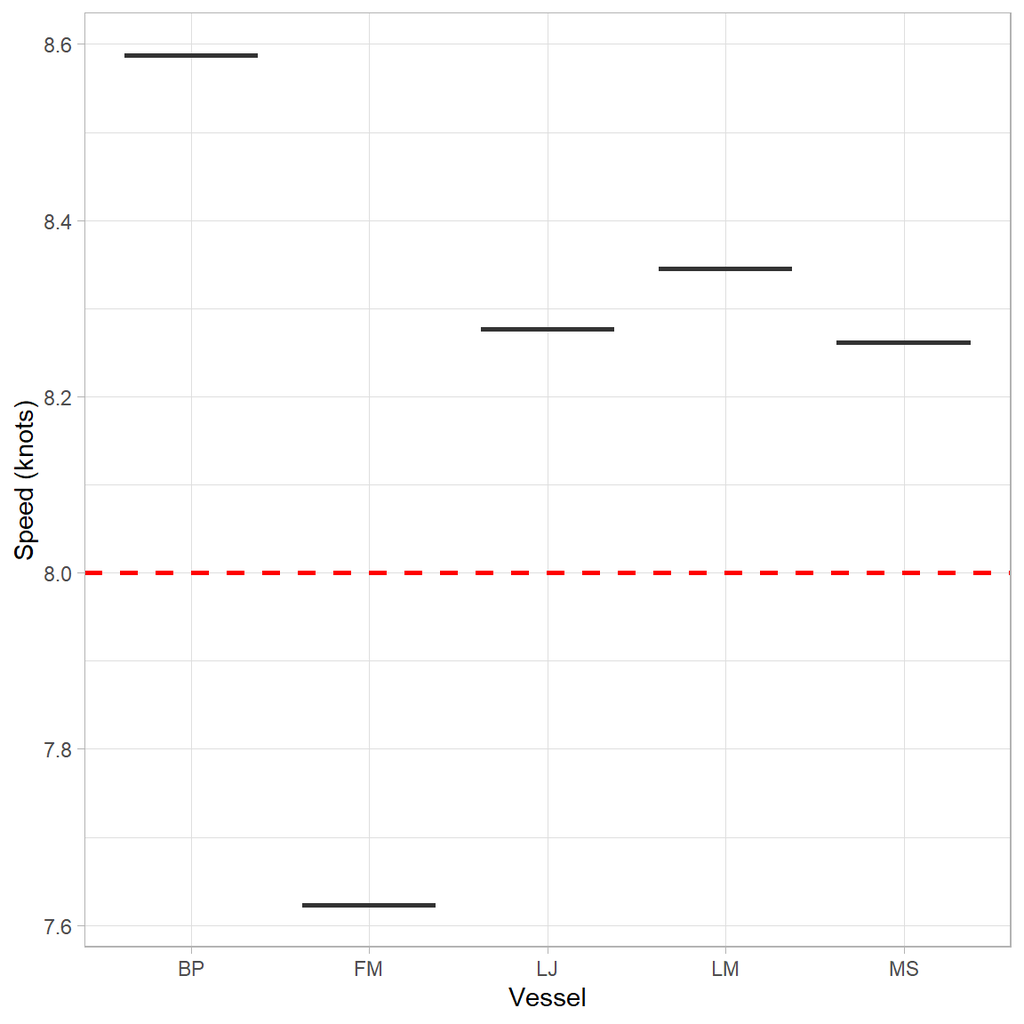

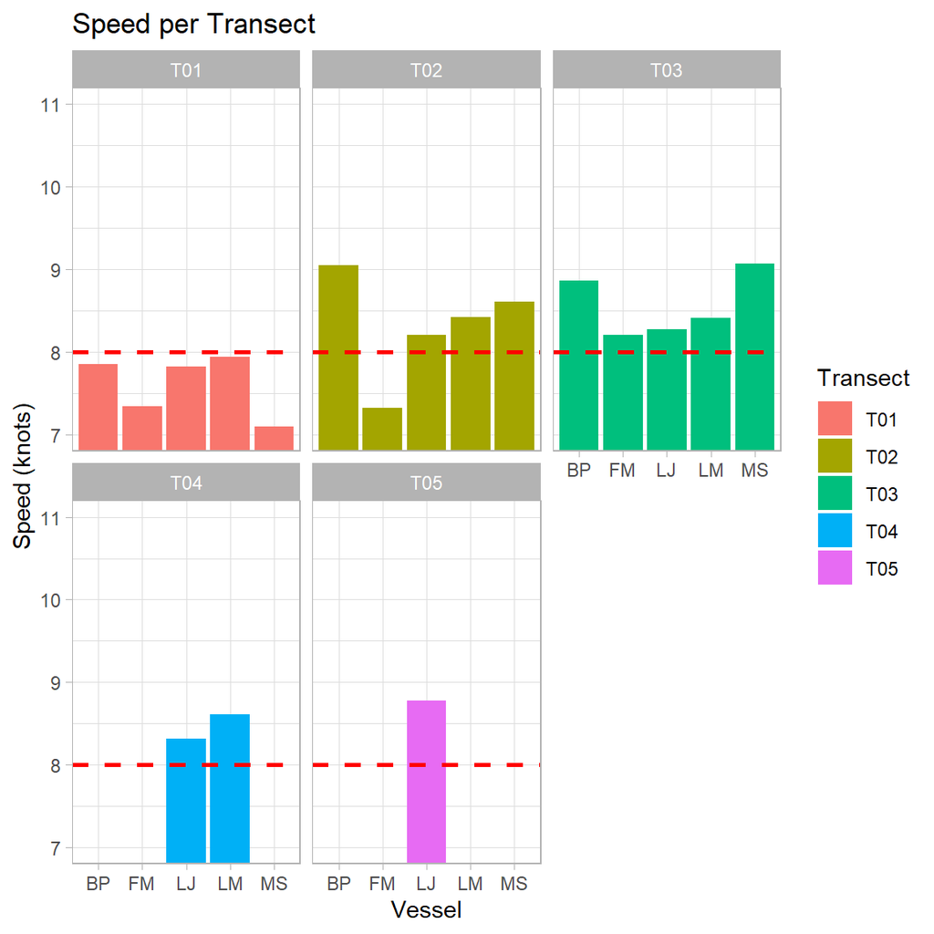

Average vessel speed was 8.22. This is above the 8 knot requirement; vessels are urged to slow down to prevent backscatter noise from interfering with the acoustic data.

The speed for each transect are rudimentary and are calculated based on distance. If a significant amount of distance is cut, the speed will appear slower.